# Utilities for Land cover/use statistics (LUCAS) data provided by EUROSTAT

## Libraries

```r
require(ggplot2)
# # Use the latest lucas code from source:
#require(devtools)
#load_all("..")
# # (OR) Use the installed package:
require(lucas)
```

## Introduction

The lucas package provides some utilities for processing Land cover/use statistics (LUCAS) data provided by EUROSTAT http://ec.europa.eu/eurostat/web/lucas. So far only LUCAS micro data (LMD) can be handeled. The most convenient functions can be used if the downloaded LMD is stored in a base directory (e.g. LMD) following the structure:

LMD/ 2006/ (data from http://ec.europa.eu/eurostat/web/lucas/data/primary-data/2006) BE_2006_0.xls CZ_2006_0.xls DE_2006_0.xls 2009/ (data from http://ec.europa.eu/eurostat/web/lucas/data/primary-data/2009) BE_2009.xls … …

A list of with the country names and codes and the years of survey data can be loaded.

```r
available_lmd <- get_lmd_overview()
available_lmd
```

| country | code | x2006 | x2009 | x2012 | x2015 | gadm |
| --- | --- | --- | --- | --- | --- | --- |
| Austria | AT | FALSE | TRUE | TRUE | TRUE | AUT |
| Belgium | BE | TRUE | TRUE | TRUE | TRUE | BEL |
| Bulgaria | BG | FALSE | FALSE | TRUE | TRUE | BGR |
| Croatia | HR | FALSE | FALSE | FALSE | TRUE | HRV |
| Cyprus | CY | FALSE | FALSE | TRUE | TRUE | CYP |
| Czech Republic | CZ | TRUE | TRUE | TRUE | TRUE | CZE |
| Denmark | DK | FALSE | TRUE | TRUE | TRUE | DNK |
| Estonia | EE | FALSE | TRUE | TRUE | TRUE | EST |
| Finland | FI | FALSE | TRUE | TRUE | TRUE | FIN |
| France | FR | TRUE | TRUE | TRUE | TRUE | FRA |

[output cut: 19 more lines]

```r
cntry <- "DE"
cntryA3 <- available_lmd$gadm[available_lmd$code==cntry]
year <- 2012
```

## Get the data - one country

You can download the data with the function get_lmd(). If on of the parameters countries and year is NULL all the corresponding data is downloaded. With the cols argument a subset of the columns can be saved. With get_lmd(destdir, countries=NULL, years=NULL) all datasets can be downloaded. The following call downloads only the data for Germany in 2012.

```r
a_tempdir <- tempdir()
a_tempdir
```

```
[1] "/tmp/RtmpeLvukB"
```

```r
lmd_subsets[["a"]]
```

```
[1] "POINT_ID" "Y_LAT"    "X_LONG"   "EW"       "LC1"      "LU1"
```

```r
lmddir <- paste0(a_tempdir, "/LMD")
get_lmd(lmddir, countries=cntry, years=year, cols=lmd_subsets[["a"]])
```

```
-----------------------------------
Downloading (1/1) DEU (DE), 2012
```

```
==================================================

Columns not found and ignored: Y_LAT, X_LONG, EW, LC1, LU1
```

```r
# Why do we get the warning if we download ?
# Columns not found and ignored: Y_LAT, X_LONG, EW, LC1, LU1
```

The column gadm gives the country code according to the ISO 3166 three letter code (see also http://userpage.chemie.fu-berlin.de/diverse/doc/ISO_3166.html). This code can be used to download the administrative boundaries from http://www.gadm.org/ with the function get_gadm(). If the destdir is given, the file will be downloaded only if it can not be found in the directory. It is also possible to get more than one country and other levels. Adding addShp=TRUE additionally writes a shapefile.

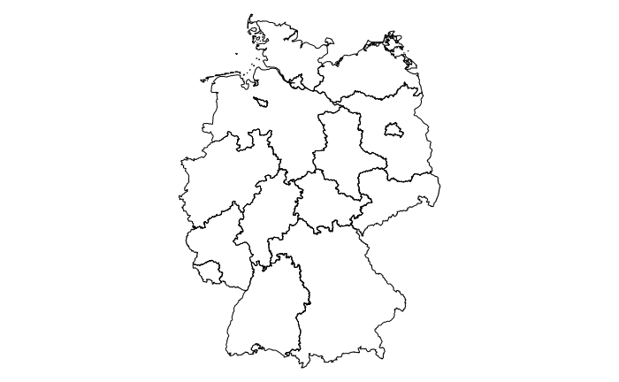

```r
gadmdir <- paste0(a_tempdir, "/GADM")
adb <- get_gadm(cntryA3, level=1, destdir=gadmdir, addShp=TRUE,
                overwrite=TRUE)
par(mar=c(0,0,0,0))
plot(adb, xlim=bbox(adb)[1,], ylim=bbox(adb)[2,])
```

With the function read_lmd() specific subsets of the data can be loaded from a specific country and year, e.g. for Germany (DE) in 2012.

```r
fn.lmd <- get_filename(lmddir = lmddir, year=2012, country="DE")
lmd <- read_lmd(fn.lmd)
head(lmd)
```

|  | Y_LAT | X_LONG | EW | LC1 | LU1 |
| --- | --- | --- | --- | --- | --- |
| 1 | 51.01099 | 5.90827 | E | A21 | U370 |
| 2 | 50.99400 | 5.93844 | E | C10 | U120 |
| 3 | 51.01302 | 5.96512 | E | B11 | U111 |
| 4 | 50.99606 | 5.99490 | E | A11 | U370 |
| 5 | 50.76366 | 6.04338 | E | B11 | U111 |
| 6 | 50.79962 | 6.04045 | E | B22 | U111 |

There is often the need to re-classify the LULC data. With the function reclassify_LULC() the columns LC1 and LU1can be re-classified. This function requires a look-up table as input which defines the reclassification rules. The first column contains the codes (can be just the initial letters then the higher level classes are extracted) and the second the new IDs. Note that all other columns are ignored.

LC1,id,class,class_abbr,color A,1,Urban,U,#b11114 B,2,Cropland,CL,#ffff99 C1,3,Broadleaf Woodland,BW,#4fc029 C2,4,Coniferous Woodland,CW,#1f601a D,5,Shrubland,SL,#d2955c E,6,Grassland,GL,#ffbc34 F,7,Bare Soil,BS,#b15928 G,8,Water,W,#1f78b4 H,9,Wetland,WL,#a6cee3

This look-up table is also stored in the package. The function reclassify_LULC() only requires a data frame as the following one:

```r
lut <- get_reclassify_lut("LC1nC9")
```

```
For the year 2006 please use LC1nC9_2006 and LC1nC10_2006 since the LUCAS Codes for Woodland (C*) are different.
```

```r
lut
```

| LC1 | id | class | class_abbr | color | red | green | blue |
| --- | --- | --- | --- | --- | --- | --- | --- |
| A | 1 | Urban | U | #b11114 | 177 | 17 | 20 |
| B | 2 | Cropland | CL | #ffff99 | 255 | 255 | 153 |
| C1 | 3 | Broadleaf Woodland | BW | #4fc029 | 79 | 192 | 41 |
| C2 | 4 | Coniferous Woodland | CW | #1f601a | 31 | 96 | 26 |
| D | 5 | Shrubland | SL | #d2955c | 210 | 149 | 92 |
| E | 6 | Grassland | GL | #ffbc34 | 255 | 188 | 52 |
| F | 7 | Bare Soil | BS | #b15928 | 177 | 89 | 40 |
| G | 8 | Water | W | #1f78b4 | 31 | 120 | 180 |
| H | 9 | Wetland | WL | #a6cee3 | 166 | 206 | 227 |

```r
lmd$LC1nC9 <- reclassify_LULC(lmd$LC1, lut)
table(lmd$LC1)
```

```
 A11  A12  A13  A21  A22  B11  B12  B13  B14  B15  B16  B17  B18  B19  B21  B22  B23  B31  B32
 538   73    4  454  760 2015   47 1114  551  108 1870    1  332    7  182  280   18   16  931
 B33  B35  B36  B37  B41  B42  B43  B44  B45  B51  B52  B53  B54  B55  B71  B72  B73  B74  B75
   2   11    1   16   56    2   74   27    8   48   26   28    7  159  162   22   38    8   28
 B82  B83  B84  C10  C21  C22  C23  C31  C32  C33  D10  D20  E10  E20  E30  F10  F20  F30  F40
  79   39    2 3224 1631 1006  216  797  778  401  197   66  589 4799  309   24   43    1  135
 G10  G20  G30  H11  H12  H21  H23
 316  133    6   89   31    6    2
```

```r
table(lmd$LC1nC9)
```

```
   0    1    2    3    4    5    6    7    8    9
1976 1829 8315 3224 2853  263 5697  203  455  128
```

```r
fn.lmd.sp <- gsub(".xls", ".shp", fn.lmd)
lmd.sp <- create_spatial_lmd(lmd, shp=fn.lmd.sp, overwrite_layer=TRUE)
```

```
Converting LMD to SpatialPointsDataFrame.
Shape file already exists: /tmp/RtmpeLvukB/LMD/2012/DE_2012.csv
```

A common task might be to create spatial subsets.

```r
adb.bavaria <- adb[adb$NAME_1=="Bayern", ]
lmd.sp.sub <- intersect_lmd(lmd.sp, adb.bavaria)
```

```
spgeom1 and spgeom2 have different proj4 strings
```

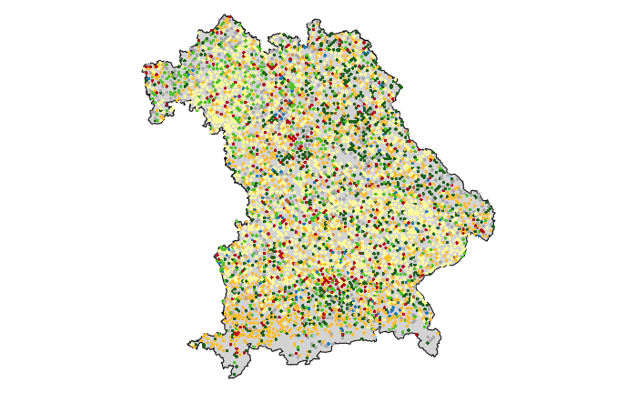

```r
par(mar=c(0,0,0,0))
plot(adb.bavaria, col="lightgrey")
plot(lmd.sp.sub, add=TRUE, pch=16, cex=.5, col=c("darkgrey", lut$color)[lmd.sp.sub@data$LC1nC9+1])
```

```r
table(lmd.sp.sub$LC1nC9)
```

```
   0    1    2    3    4    5    6    7    8    9
 509  323 1475  528  774   38 1134   28   96   16
```

```r
table(lmd.sp.sub$LC1nC9)
```

```
   0    1    2    3    4    5    6    7    8    9
 509  323 1475  528  774   38 1134   28   96   16
```

Merge LMD data

```r
cntrs <- c("DE", "AT")
cntrsA3 <- available_lmd$gadm[available_lmd$code %in% cntrs]
```

```r
fn.lmd.sp <- paste0(lmddir,  "/DEU_AUT_2012.shp")
lmd <- c()
for (cntry in cntrs) {
  get_lmd(lmddir, countries=cntry, years=2012, cols=lmd_subsets[["a"]])
  fn.lmd <- get_filename(lmddir = lmddir, year = 2012, country = cntry)
  lmd <- rbind(lmd, read_lmd(fn.lmd))
}
```

```
-----------------------------------
Downloading (1/1) DEU (DE), 2012
LMD already exists. Loaded from /tmp/RtmpeLvukB/LMD/2012/DE_2012.csv
```

```
Columns not found and ignored: Y_LAT, X_LONG, EW, LC1, LU1
```

```
-----------------------------------
Downloading (1/1) AUT (AT), 2012
```

```
==================================================

Columns not found and ignored: Y_LAT, X_LONG, EW, LC1, LU1
```

```r
lmd$LC1nc9 <- reclassify_LULC(lmd$LC1, lut)
lmd.sp <- create_spatial_lmd(lmd, shp=fn.lmd.sp, overwrite_layer=TRUE)
```

```
Converting LMD to SpatialPointsDataFrame.
Saving LMD as ESRI Shapefile to /tmp/RtmpeLvukB/LMD/DEU_AUT_2012.shp
```

[figure not shown]

```r
plot(lmd.sp, pch=16, cex=.1, col=c("darkgrey", lut$color)[lmd.sp.sub@data$LC1nC9+1])
```

Each LMD point carries a lot of metadata information. Some basic information about the metadata can be extracted with info_LMD_table(). For example, the list of attributes:

```r
info_LMD_table_attributes()
```

```
LMD attributes:
  - POINT_ID
  - X_LAEA
  - Y_LAEA
  - STRATA
  - STRATA2
  - NUTS0
  - NUTS1
  - NUTS2
  - SURV_DATE
  - OBSERVED
  - OBS_TYPE
  - GPS_PROJ
  - GPS_PREC
  - GPS_Y_LAT
  - GPS_EW
  - GPS_X_LONG
  - OBS_DIST
  - Y_LAT
  - EW
  - X_LONG
  - OBS_DIST
  - OBS_DIRECT
  - LC1
  - LC2
  - OBS_RADIUS
  - LU1
  - LU2
  - LC1_SPECIES
  - LC1_PERCENT
  - LC2_SPECIES
  - LC2_PERCENT
  - AREA_SIZE
  - TREE_HEIGHT_SURVEY
  - TREE_HEIGHT_MATURITY
  - FEATURE_WIDTH
  - LAND_MNGT
  - LC_LU_SPECIAL_REMARK
  - SPECIAL_STATUS
  - WM_WATER_MNGT
  - WM_SRC_IRRIGATION
  - WM_TYP_IRRIGATION
  - WM_DELIVERY_SYST
  - SOIL_SURVEY
  - SOIL_PLOUGH
  - SOIL_CROP
  - SOIL_STONES
  - PHOTO_POINT
  - PHOTO_N
  - PHOTO_E
  - PHOTO_S
  - PHOTO_W
  - TR1 ... TR80
```

And (if applicable) a more detailed description of the possible values of the attributes:

```r
info_LMD_table(attr=c("LC1", "OBS_RADIUS", "AREA_SIZE"))
```

```
************
LC1 | Land Cover 1 | Text
VALUES:
    See file 'Nomenclature_LC_LU_LC species' Annex1
************
OBS_RADIUS | Observation radius | Number
VALUES:
    1= 1.5m;
    2=20m
************
AREA_SIZE | Size of the area | Number
VALUES:
    1=less than 0.5ha;
    2= between 0.5ha and 1ha;
    3= between 1ha and 10ha;
    4= more than 10ha;
    8= N.R.
```

Lucas has a strict separation between Land cover and Land Use classes. The variables are stored in the fields LC1 and LU1. The class definitions can are described here: http://ec.europa.eu/eurostat/documents/205002/208012/LUCAS2012_C3-Classification_20131004_0.pdf/a71e46b5-a14b-4c9e-83ed-4f973dc139e0)

Specific combinations of the information gives the specific LULC Class. For example, the land cover class Buildings with one to three floors (A11) combined with the the land use class Agriculture (excluding fallow land and kitchen gardens) (U111) is defined as Small agricultural buildings, farms, stables, poultry yards.

The LC1 x LU1 matrix can be created as follows:

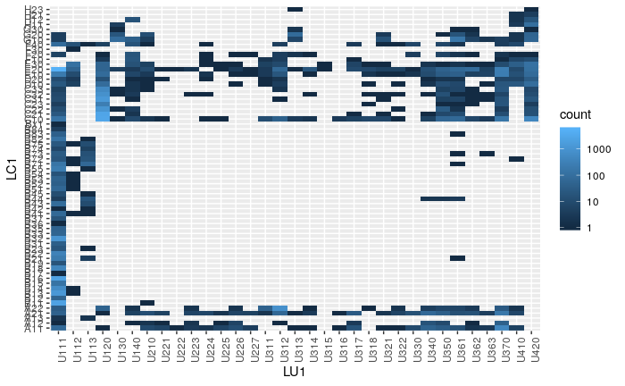

```r
lclu <- get_LC1xLU1_counts(lmd)
my_breaks = c(1, 10, 100, 1000, 10000)
ggplot(lclu, aes(LU1, LC1)) + geom_raster(aes(fill = count)) +
    scale_fill_gradient(name = "count", trans = "log", breaks = my_breaks, labels = my_breaks) +
    theme(axis.text.x = element_text(angle = 90, hjust = 1))
```